# Módulo3

María José Guzmán

2024-01-04

# Cargar paquetes

```r
library(readxl)
library (stats)
library(forecast)
library(dplyr)
library(GGally)
library(car)
```

# Sección A

**Ve al Banco Central y obtén las siguientes variables: Oferta Monetaria, Exportaciones**

```r
datos <- read_excel("C:/Users/maria/Dropbox/Acádemico/Análisis de datos/Módulo 3/TrabajoFinal/Datos.xlsx")
```

```r
tsbase = ts(datos, start=c(2021,1), frequency = 12)
```

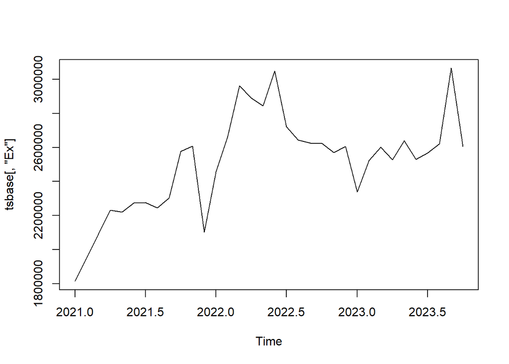

```r
plot(tsbase[,"Ex"])
```

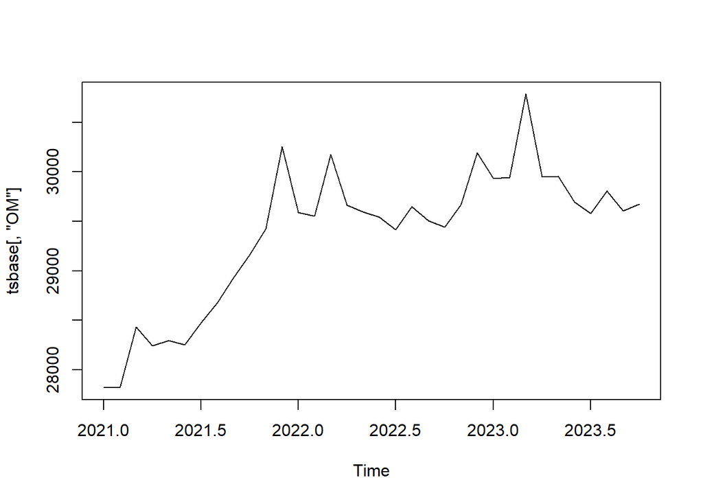

```r
plot(tsbase[,"OM"])
```

**Calcula para cada variable la tasa de crecimiento promedio a través de los modelos aprendidos en las lecciones, reporta los resultados de la regresón y explica el coeficiente en cuestión**

```r
exportaciones <- tslm(log(tsbase[,"Ex"]) ~ trend, data = tsbase)
summary(exportaciones)
```

```
##
## Call:
## tslm(formula = log(tsbase[, "Ex"]) ~ trend, data = tsbase)
##
## Residuals:
##      Min       1Q   Median       3Q      Max
## -0.19181 -0.06384 -0.01138  0.06669  0.19665
##
## Coefficients:
##              Estimate Std. Error t value Pr(>|t|)
## (Intercept) 14.595710   0.032985 442.495  < 2e-16 ***
## trend        0.007640   0.001644   4.647 5.53e-05 ***
## ---
## Signif. codes:  0 '***' 0.001 '**' 0.01 '*' 0.05 '.' 0.1 ' ' 1
##
## Residual standard error: 0.09405 on 32 degrees of freedom
## Multiple R-squared:  0.4029, Adjusted R-squared:  0.3843
## F-statistic:  21.6 on 1 and 32 DF,  p-value: 5.526e-05
```

```r
(exp(0.007640)-1)*100
```

```
## [1] 0.7669259
```

La tasa de crecimiento relativa compuesta para el periodo 2021M1 y 2023M10 es de 0.767, es decir en promedio mes a mes para el periodo 2021 a 2023 las exportaciones se incrementaron mensualmente 0.767%

```r
ofertam <- tslm(log(tsbase[,"OM"]) ~ trend, data = tsbase)
summary(ofertam)
```

```
##
## Call:
## tslm(formula = log(tsbase[, "OM"]) ~ trend, data = tsbase)
##
## Residuals:
##       Min        1Q    Median        3Q       Max
## -0.024377 -0.012856 -0.000850  0.008397  0.040402
##
## Coefficients:
##              Estimate Std. Error  t value Pr(>|t|)
## (Intercept) 1.025e+01  5.640e-03 1818.071  < 2e-16 ***
## trend       1.920e-03  2.811e-04    6.828 1.01e-07 ***
## ---
## Signif. codes:  0 '***' 0.001 '**' 0.01 '*' 0.05 '.' 0.1 ' ' 1
##
## Residual standard error: 0.01608 on 32 degrees of freedom
## Multiple R-squared:  0.593,  Adjusted R-squared:  0.5803
## F-statistic: 46.63 on 1 and 32 DF,  p-value: 1.01e-07
```

```r
(exp(1.920e-03)-1)*100
```

```
## [1] 0.1921844
```

La tasa de crecimiento relativa compuesta para el periodo 2021M1 y 2023M10 es de 0.192, es decir en promedio mes a mes para el periodo 2021 a 2023 la oferta monetaria se incrementaron mensualmente 0.192%

# Sección B

**Investiga en internet un modelo de regresión múltiple que considere la variable “Y” y al menos 2 variables X**

Un estudio quiere generar un modelo que permita predecir la esperanza de vida media de los habitantes de una ciudad en función de diferentes variables. Se dispone de información sobre: habitantes, analfabetismo, ingresos, esperanza de vida, asesinatos, universitarios, heladas, área y densidad poblacional.

```r
datos <- as.data.frame(state.x77)
datos <- rename(habitantes = Population, analfabetismo = Illiteracy,
                ingresos = Income, esp_vida = `Life Exp`, asesinatos = Murder,
                universitarios = `HS Grad`, heladas = Frost, area = Area,
                .data = datos)
datos <- mutate(.data = datos, densidad_pobl = habitantes * 1000 / area)
```

**Realiza la estimación de la regresión, reporta los resultados e interpreta los coeficientes. No olvides mencionar las pruebas de significancia individual, Aplica los contrastes aprendidos para identificar Autocorrelación, Heterocedasticidad, Multicolinealidad. Procede a atenuar con algún método, dependiendo de la dolencia del modelo. Reporta los resultados finales.**

1. Analizar correlación

```r
round(cor(x = datos, method = "pearson"), 3)
```

```
##                habitantes ingresos analfabetismo esp_vida asesinatos
## habitantes          1.000    0.208         0.108   -0.068      0.344
## ingresos            0.208    1.000        -0.437    0.340     -0.230
## analfabetismo       0.108   -0.437         1.000   -0.588      0.703
## esp_vida           -0.068    0.340        -0.588    1.000     -0.781
## asesinatos          0.344   -0.230         0.703   -0.781      1.000
## universitarios     -0.098    0.620        -0.657    0.582     -0.488
## heladas            -0.332    0.226        -0.672    0.262     -0.539
## area                0.023    0.363         0.077   -0.107      0.228
## densidad_pobl       0.246    0.330         0.009    0.091     -0.185
##                universitarios heladas   area densidad_pobl
## habitantes             -0.098  -0.332  0.023         0.246
## ingresos                0.620   0.226  0.363         0.330
## analfabetismo          -0.657  -0.672  0.077         0.009
## esp_vida                0.582   0.262 -0.107         0.091
## asesinatos             -0.488  -0.539  0.228        -0.185
## universitarios          1.000   0.367  0.334        -0.088
## heladas                 0.367   1.000  0.059         0.002
## area                    0.334   0.059  1.000        -0.341
## densidad_pobl          -0.088   0.002 -0.341         1.000
```

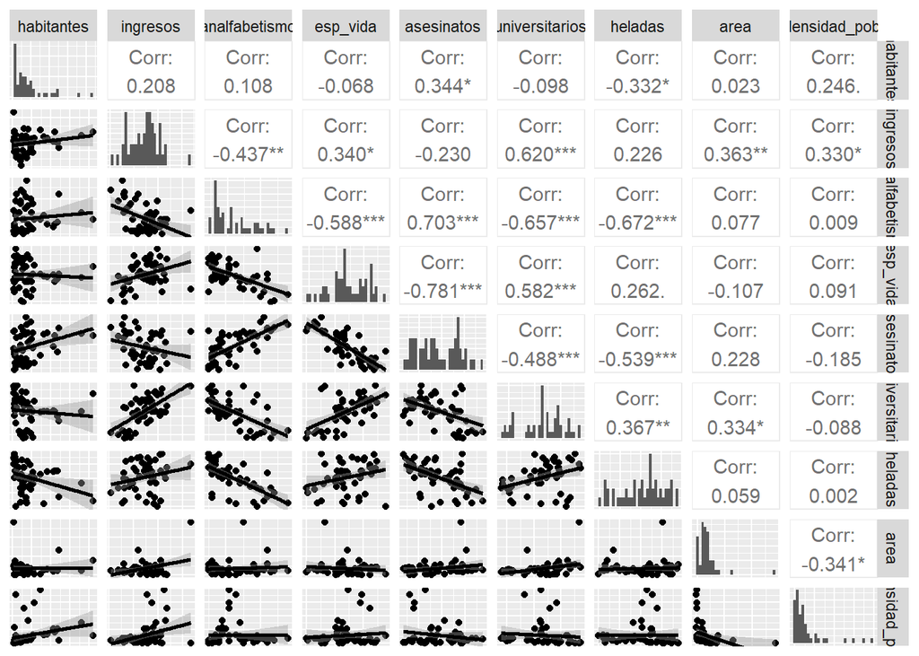

```r
ggpairs(datos, lower = list(continuous = "smooth"),
        diag = list(continuous = "barDiag"), axisLabels = "none")
```

Del análisis preliminar se pueden extraer las siguientes conclusiones:

- Las variables que tienen una mayor relación lineal con la esperanza de vida son: asesinatos (r= -0.78), analfabetismo (r= -0.59) y universitarios (r= 0.58).
- Asesinatos y analfabetismo están medianamente correlacionados (r = 0.7) por lo que posiblemente no sea útil introducir ambos predictores en el modelo.
- Las variables habitantes, área y densidad poblacional muestran una distribución exponencial, una transformación logarítmica posiblemente haría más normal su distribución.
2. Generación del modelo

```r
mod1 <- lm(esp_vida ~ habitantes + ingresos + analfabetismo + asesinatos +
               universitarios + heladas + area + densidad_pobl, data = datos )
summary(mod1)
```

```
##
## Call:
## lm(formula = esp_vida ~ habitantes + ingresos + analfabetismo +
##     asesinatos + universitarios + heladas + area + densidad_pobl,
##     data = datos)
##
## Residuals:
##      Min       1Q   Median       3Q      Max
## -1.47514 -0.45887 -0.06352  0.59362  1.21823
##
## Coefficients:
##                  Estimate Std. Error t value Pr(>|t|)
## (Intercept)     6.995e+01  1.843e+00  37.956  < 2e-16 ***
## habitantes      6.480e-05  3.001e-05   2.159   0.0367 *
## ingresos        2.701e-04  3.087e-04   0.875   0.3867
## analfabetismo   3.029e-01  4.024e-01   0.753   0.4559
## asesinatos     -3.286e-01  4.941e-02  -6.652 5.12e-08 ***
## universitarios  4.291e-02  2.332e-02   1.840   0.0730 .
## heladas        -4.580e-03  3.189e-03  -1.436   0.1585
## area           -1.558e-06  1.914e-06  -0.814   0.4205
## densidad_pobl  -1.105e-03  7.312e-04  -1.511   0.1385
## ---
## Signif. codes:  0 '***' 0.001 '**' 0.01 '*' 0.05 '.' 0.1 ' ' 1
##
## Residual standard error: 0.7337 on 41 degrees of freedom
## Multiple R-squared:  0.7501, Adjusted R-squared:  0.7013
## F-statistic: 15.38 on 8 and 41 DF,  p-value: 3.787e-10
```

El modelo con todas las variables introducidas como predictores tiene un R2 alta (0.7501), es capaz de explicar el 75,01% de la variabilidad observada en la esperanza de vida. El p-value del modelo es significativo (3.787e-10) por lo que se puede aceptar que el modelo no es por azar, al menos uno de los coeficientes parciales de regresión es distinto de 0. Muchos de ellos no son significativos, lo que es un indicativo de que podrían no contribuir al modelo

2. Heterocedasticidad

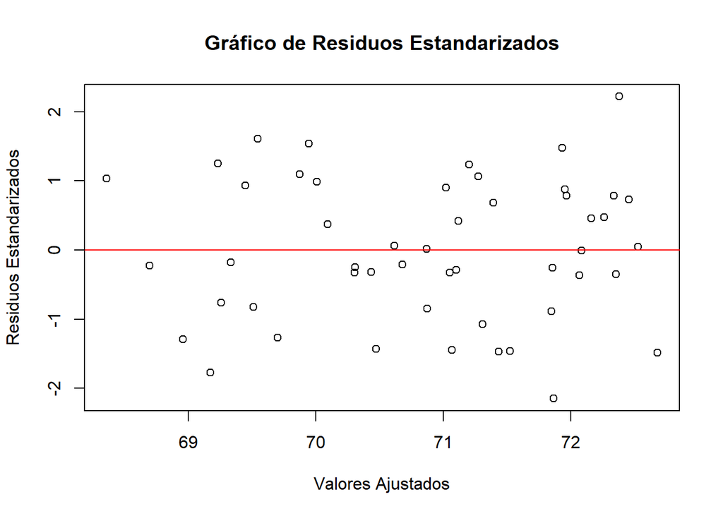

```r
residuos_estandarizados <- rstandard(mod1)

plot(fitted(mod1), residuos_estandarizados, ylab = "Residuos Estandarizados", xlab = "Valores Ajustados", main = "Gráfico de Residuos Estandarizados")
abline(h = 0, col = "red")
```

A nivel gráfico no se observan patrones de heteroscedasticidad en el modelo

3. Multicolinealidad

```r
vif(mod1)
```

```
##     habitantes       ingresos  analfabetismo     asesinatos universitarios
##       1.634268       3.275340       5.475516       3.028169       3.229221
##        heladas           area  densidad_pobl
##       2.501893       2.429078       2.377250
```

Al revisar multicolinealidad se observa que en el caso de ingresos, analfabetismo, asesinatos, universitarios heladas, área y densidad poblacional los valores se consideran altos, mayores a 2 por lo tanto para mejorar el modelo debido a la alta correlación se utiliza la estrategia de stepwise mixto. El valor matemático empleado para determinar la calidad del modelo va a ser Akaike(AIC).

4. Selección del mejor modelo:

```r
step(object = mod1, direction = "both", trace = 1)
```

```
## Start:  AIC=-22.89
## esp_vida ~ habitantes + ingresos + analfabetismo + asesinatos +
##     universitarios + heladas + area + densidad_pobl
##
##                  Df Sum of Sq    RSS     AIC
## - analfabetismo   1    0.3050 22.373 -24.208
## - area            1    0.3564 22.425 -24.093
## - ingresos        1    0.4120 22.480 -23.969
## <none>                        22.068 -22.894
## - heladas         1    1.1102 23.178 -22.440
## - densidad_pobl   1    1.2288 23.297 -22.185
## - universitarios  1    1.8225 23.891 -20.926
## - habitantes      1    2.5095 24.578 -19.509
## - asesinatos      1   23.8173 45.886  11.707
##
## Step:  AIC=-24.21
## esp_vida ~ habitantes + ingresos + asesinatos + universitarios +
##     heladas + area + densidad_pobl
##
##                  Df Sum of Sq    RSS     AIC
## - area            1    0.1427 22.516 -25.890
## - ingresos        1    0.2316 22.605 -25.693
## <none>                        22.373 -24.208
## - densidad_pobl   1    0.9286 23.302 -24.174
## - universitarios  1    1.5218 23.895 -22.918
## + analfabetismo   1    0.3050 22.068 -22.894
## - habitantes      1    2.2047 24.578 -21.509
## - heladas         1    3.1324 25.506 -19.656
## - asesinatos      1   26.7071 49.080  13.072
##
## Step:  AIC=-25.89
## esp_vida ~ habitantes + ingresos + asesinatos + universitarios +
##     heladas + densidad_pobl
##
##                  Df Sum of Sq    RSS     AIC
## - ingresos        1     0.132 22.648 -27.598
## - densidad_pobl   1     0.786 23.302 -26.174
## <none>                        22.516 -25.890
## - universitarios  1     1.424 23.940 -24.824
## + area            1     0.143 22.373 -24.208
```

[output cut: 18 more lines]

```
## - asesinatos      1    33.626 56.274  15.910
##
## Step:  AIC=-28.16
## esp_vida ~ habitantes + asesinatos + universitarios + heladas
##
##                  Df Sum of Sq    RSS     AIC
## <none>                        23.308 -28.161
## + densidad_pobl   1     0.660 22.648 -27.598
## + ingresos        1     0.006 23.302 -26.174
## + analfabetismo   1     0.004 23.304 -26.170
## + area            1     0.001 23.307 -26.163
## - habitantes      1     2.064 25.372 -25.920
## - heladas         1     3.122 26.430 -23.877
## - universitarios  1     5.112 28.420 -20.246
## - asesinatos      1    34.816 58.124  15.528
```

```
##
## Call:
## lm(formula = esp_vida ~ habitantes + asesinatos + universitarios +
##     heladas, data = datos)
##
## Coefficients:
##    (Intercept)      habitantes      asesinatos  universitarios         heladas
##      7.103e+01       5.014e-05      -3.001e-01       4.658e-02      -5.943e-03
```

5. Mejor modelo

```r
mod2 <- (lm(formula = esp_vida ~ habitantes + asesinatos + universitarios +
              heladas, data = datos))
summary(mod2)
```

```
##
## Call:
## lm(formula = esp_vida ~ habitantes + asesinatos + universitarios +
##     heladas, data = datos)
##
## Residuals:
##      Min       1Q   Median       3Q      Max
## -1.47095 -0.53464 -0.03701  0.57621  1.50683
##
## Coefficients:
##                  Estimate Std. Error t value Pr(>|t|)
## (Intercept)     7.103e+01  9.529e-01  74.542  < 2e-16 ***
## habitantes      5.014e-05  2.512e-05   1.996  0.05201 .
## asesinatos     -3.001e-01  3.661e-02  -8.199 1.77e-10 ***
## universitarios  4.658e-02  1.483e-02   3.142  0.00297 **
## heladas        -5.943e-03  2.421e-03  -2.455  0.01802 *
## ---
## Signif. codes:  0 '***' 0.001 '**' 0.01 '*' 0.05 '.' 0.1 ' ' 1
##
## Residual standard error: 0.7197 on 45 degrees of freedom
## Multiple R-squared:  0.736,  Adjusted R-squared:  0.7126
## F-statistic: 31.37 on 4 and 45 DF,  p-value: 1.696e-12
```

6. Multicolinealidad de nuevo

```r
vif(mod2)
```

```
##     habitantes     asesinatos universitarios        heladas
##       1.189835       1.727844       1.356791       1.498077
```

Se observa que los valores no estan correlacionados con otros y que sus valores son menores a 2 lo que se considera bajos.

7. Intervalos de confianza:

```r
confint(lm(formula = esp_vida ~ habitantes + asesinatos + universitarios +
            heladas, data = datos))
```

```
##                        2.5 %        97.5 %
## (Intercept)     6.910798e+01 72.9462729104
## habitantes     -4.543308e-07  0.0001007343
## asesinatos     -3.738840e-01 -0.2264135705
## universitarios  1.671901e-02  0.0764454870
## heladas        -1.081918e-02 -0.0010673977
```

Cada una de las pendientes de un modelo de regresión lineal múltiple (coeficientes parciales de regresión de los predictores) se define del siguiente modo: Si el resto de variables se mantienen constantes, por cada unidad que aumenta el predictor en cuestión, la variable (Y) varía en promedio tantas unidades como indica la pendiente. Para este ejemplo, por cada unidad que aumenta el predictor universitarios, la esperanza de vida aumenta en promedio 0.04658 unidades, manteniéndose constantes el resto de predictores.